# Trabajo Práctico final: Modelos Lineales Mixtos

Enfoque Estadístico del Aprendizaje

Ignacio Linari

2024-12-15

## Introducción

```r
rm(list = ls()) # Borro todos los objetos
gc() # Garbage Collection
```

```
##           used (Mb) gc trigger (Mb) limit (Mb) max used (Mb)
## Ncells  551939 29.5    1226845 65.6         NA   700245 37.4
## Vcells 1026390  7.9    8388608 64.0      16384  1963153 15.0
```

```r
# Leer los datos
soja_data <- read.csv("/Users/ignacio/Downloads/soja_total_serie.csv", encoding = "latin1")
```

## Análisis exploratorio

```r
# Estadística descriptiva básica
library(dplyr)
library(ggplot2)
library(tidyr)
library(GGally)

# Resumen numérico de las variables cuantitativas
summary(select(soja_data, where(is.numeric)))
```

```
##       anio       provincia_id  departamento_id superficie_sembrada_ha
##  Min.   :2000   Min.   : 6.0   Min.   : 6007   Min.   :     0
##  1st Qu.:2005   1st Qu.: 6.0   1st Qu.: 6547   1st Qu.:  2748
##  Median :2010   Median :18.0   Median :18035   Median : 13000
##  Mean   :2010   Mean   :31.8   Mean   :31927   Mean   : 37087
##  3rd Qu.:2015   3rd Qu.:54.0   3rd Qu.:54112   3rd Qu.: 41500
##  Max.   :2019   Max.   :90.0   Max.   :90119   Max.   :859273
##                                NA's   :52
##  superficie_cosechada_ha produccion_tm     rendimiento_kgxha
##  Min.   :     0          Min.   :      0   Min.   :   0
##  1st Qu.:  2500          1st Qu.:   4642   1st Qu.:1757
##  Median : 12490          Median :  25900   Median :2300
##  Mean   : 36046          Mean   :  98488   Mean   :2306
##  3rd Qu.: 40000          3rd Qu.:  96600   3rd Qu.:2800
##  Max.   :850273          Max.   :2550819   Max.   :9156
##                          NA's   :3         NA's   :3
```

```r
# Verificar valores ausentes
colSums(is.na(soja_data))
```

```
##          cultivo_nombre                    anio                campania
##                       0                       0                       0
##        provincia_nombre            provincia_id     departamento_nombre
##                       0                       0                       0
##         departamento_id  superficie_sembrada_ha superficie_cosechada_ha
##                      52                       0                       0
##           produccion_tm       rendimiento_kgxha
##                       3                       3
```

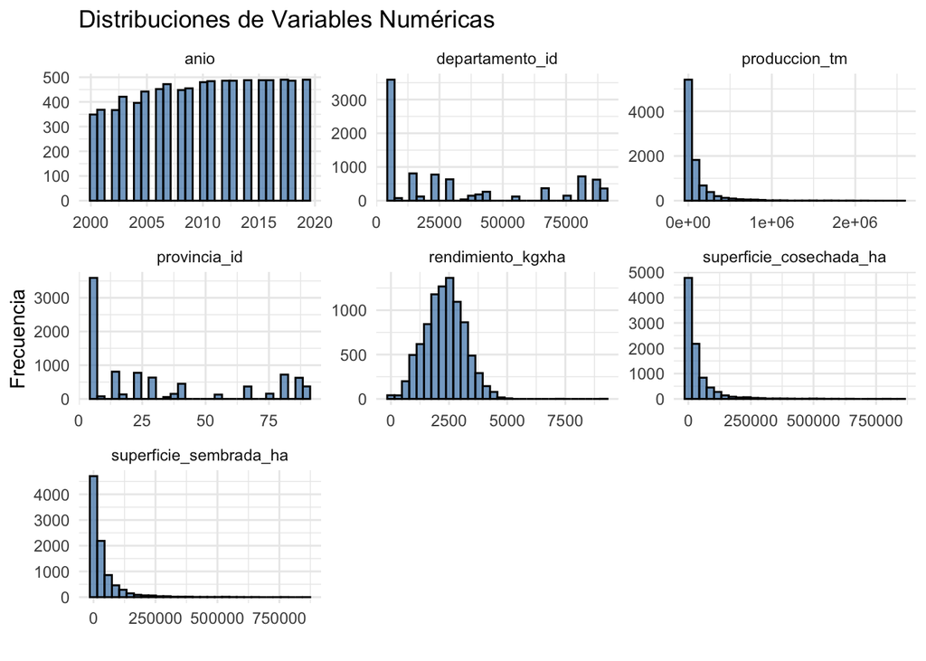

```r
# Visualización: distribuciones de las variables numéricas
soja_data %>%
  select(where(is.numeric)) %>%
  pivot_longer(cols = everything(), names_to = "Variable", values_to = "Valor") %>%
  ggplot(aes(x = Valor)) +
  geom_histogram(bins = 30, fill = "steelblue", color = "black", alpha = 0.7) +
  facet_wrap(~ Variable, scales = "free") +
  theme_minimal() +
  labs(title = "Distribuciones de Variables Numéricas", x = "", y = "Frecuencia")
```

```r
# Resumen de variables categóricas
soja_data %>%
  select(where(is.character)) %>%
  summarise(across(everything(), ~ length(unique(.)))) %>%
  t() %>%
  data.frame() %>%
  setNames(c("Niveles Únicos"))
```

|  | Niveles Únicos |
| --- | --- |
| cultivo_nombre | 2 |
| campania | 20 |
| provincia_nombre | 15 |
| departamento_nombre | 272 |

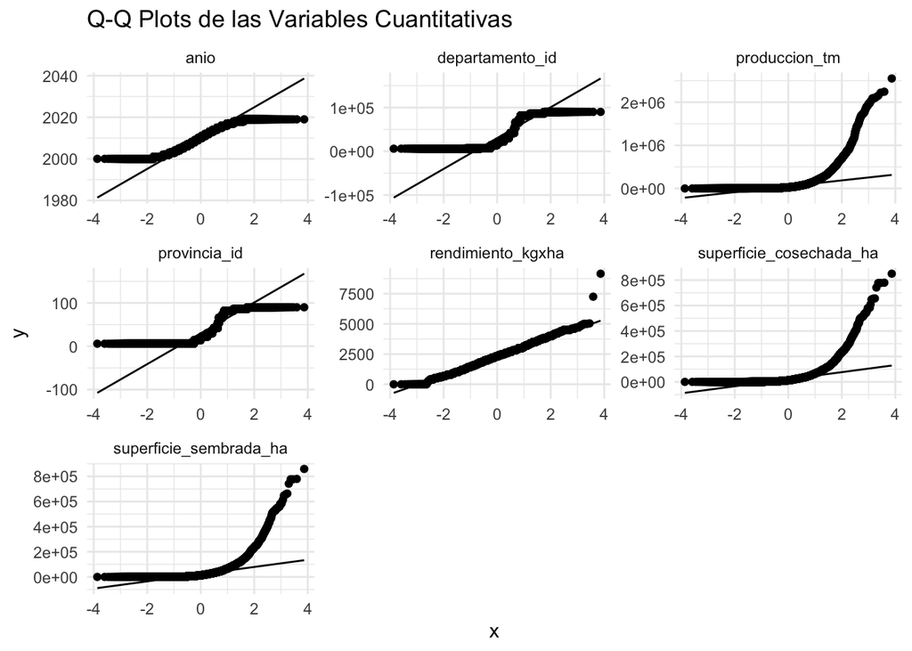

```r
# Q-Q plots para todas las variables cuantitativas
soja_data %>%
  select(where(is.numeric)) %>%
  pivot_longer(cols = everything(), names_to = "Variable", values_to = "Valor") %>%
  ggplot(aes(sample = Valor)) +
  stat_qq() +
  stat_qq_line() +
  facet_wrap(~ Variable, scales = "free") +
  theme_minimal() +
  labs(title = "Q-Q Plots de las Variables Cuantitativas")
```

```r
# Pruebas de normalidad para cada variable numérica (submuestreo de 5000 observaciones para validez de test)
soja_data %>%
  select(where(is.numeric)) %>%
  summarise(across(everything(), ~ shapiro.test(sample(., size = min(length(.), 5000)))$p.value)) %>%
  pivot_longer(cols = everything(), names_to = "Variable", values_to = "p_value") %>%
  mutate(Normalidad = ifelse(p_value > 0.05, "Sí", "No"))
```

| Variable | p_value | Normalidad |
| --- | --- | --- |
| anio | 3.813279e-37 | No |
| provincia_id | 1.530262e-64 | No |
| departamento_id | 5.411779e-64 | No |
| superficie_sembrada_ha | 8.251672e-77 | No |
| superficie_cosechada_ha | 1.805790e-77 | No |
| produccion_tm | 3.230086e-80 | No |
| rendimiento_kgxha | 5.869924e-16 | No |

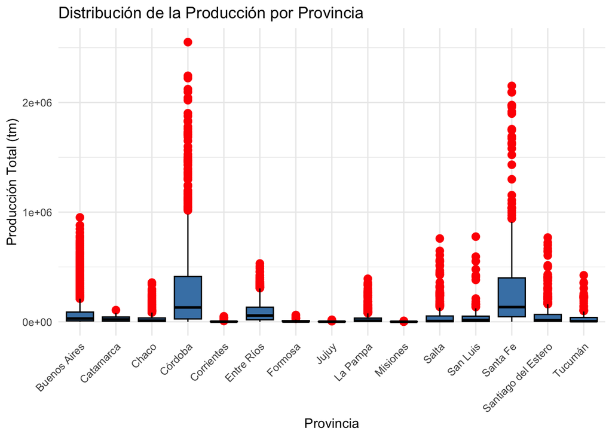

```r
# Crear boxplot por provincia para identificar outliers en la variable "produccion_tm"
ggplot(soja_data, aes(x = provincia_nombre, y = produccion_tm)) +
  geom_boxplot(fill = "steelblue", color = "black", outlier.colour = "red", outlier.shape = 16, outlier.size = 3) +
  theme_minimal() +
  labs(title = "Distribución de la Producción por Provincia",
       x = "Provincia",
       y = "Producción Total (tm)") +
  theme(axis.text.x = element_text(angle = 45, hjust = 1))  # Para que los nombres de las provincias sean legibles
```

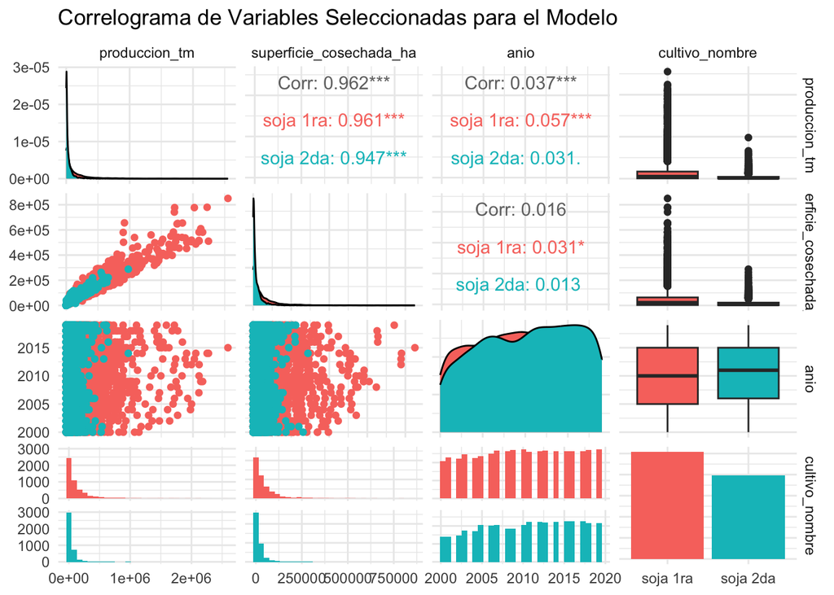

```r
# Filtrar solo las variables que se usarán en el modelo
soja_data_modelo <- soja_data %>%
  select(produccion_tm, superficie_cosechada_ha, anio, cultivo_nombre)#, provincia_nombre)#, departamento_nombre)

# Crear el correlograma
ggpairs(soja_data_modelo,
        mapping = aes(color = cultivo_nombre),
        title = "Correlograma de Variables Seleccionadas para el Modelo") +
  theme_minimal() +
  theme(legend.position = "bottom")
```

Vemos que no se cumplen los supuestos de nomralidad y homocedasticidad, además de la presencia de valores atípicos en la variable “produccion_tm”. Por lo tanto, es lógico ajustar un modelo lineal mixto robusto para mitigar estos problemas. Pero cabe destacar la fuerte correlacion entre las variables “superficie_cosechada_ha” y “produccion_tm”, lo que indica que la superficie cosechada es un predictor importante de la producción de soja y por eso para empezar se hará un ajuste lineal simple para usar como referencia.

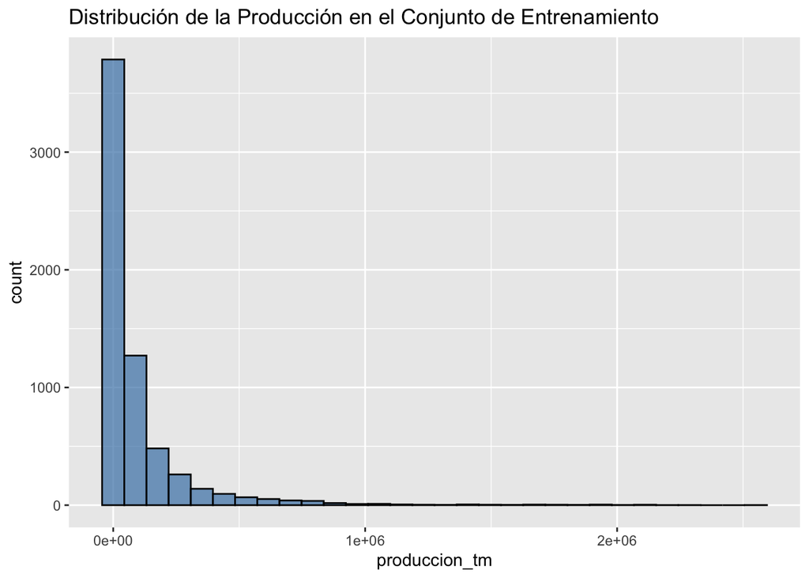

```r
# Dividir los datos en entrenamiento (70%) y prueba (30%)
set.seed(123)  # Para que los resultados sean reproducibles
indice_entrenamiento <- sample(1:nrow(soja_data), size = 0.7 * nrow(soja_data))
soja_entrenamiento <- soja_data[indice_entrenamiento, ]
soja_prueba <- soja_data[-indice_entrenamiento, ]

# Verificación de la distribución de los datos
ggplot(soja_entrenamiento, aes(x = produccion_tm)) +
  geom_histogram(fill = "steelblue", color = "black", alpha = 0.7) +
  ggtitle("Distribución de la Producción en el Conjunto de Entrenamiento")
```

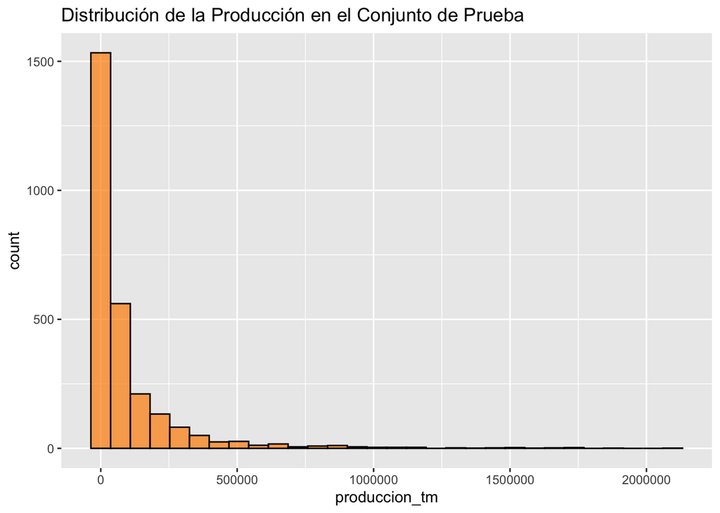

```r
ggplot(soja_prueba, aes(x = produccion_tm)) +
  geom_histogram(fill = "darkorange", color = "black", alpha = 0.7) +
  ggtitle("Distribución de la Producción en el Conjunto de Prueba")
```

Vemos que se mantienen las distribuciones en ambas particiones, lo que indica que la división fue aleatoria y no sesgada.

```r
# Ajustar un modelo lineal simple
modelo_lineal_simple <- lm(produccion_tm ~ superficie_cosechada_ha, data = soja_entrenamiento)

# Resumen del modelo lineal simple
summary(modelo_lineal_simple)
```

```
##
## Call:
## lm(formula = produccion_tm ~ superficie_cosechada_ha, data = soja_entrenamiento)
##
## Residuals:
##     Min      1Q  Median      3Q     Max
## -627628   -7355    6776   10012  712085
##
## Coefficients:
##                           Estimate Std. Error t value Pr(>|t|)
## (Intercept)             -1.022e+04  7.808e+02  -13.09   <2e-16 ***
## superficie_cosechada_ha  3.021e+00  1.028e-02  293.85   <2e-16 ***
## ---
## Signif. codes:  0 '***' 0.001 '**' 0.01 '*' 0.05 '.' 0.1 ' ' 1
##
## Residual standard error: 54490 on 6320 degrees of freedom
##   (3 observations deleted due to missingness)
## Multiple R-squared:  0.9318, Adjusted R-squared:  0.9318
## F-statistic: 8.635e+04 on 1 and 6320 DF,  p-value: < 2.2e-16
```

```r
# Realizar predicciones con el modelo lineal simple en el conjunto de prueba
predicciones_lineal_simple <- predict(modelo_lineal_simple, newdata = soja_prueba)

# Calcular el RMSE (Root Mean Squared Error)
rmse_lineal_simple <- sqrt(mean((soja_prueba$produccion_tm - predicciones_lineal_simple)^2))

# Calcular el MAE (Mean Absolute Error)
mae_lineal_simple <- mean(abs(soja_prueba$produccion_tm - predicciones_lineal_simple))

# Calcular el MSE (Mean Squared Error)
mse_lineal_simple <- mean((soja_prueba$produccion_tm - predicciones_lineal_simple)^2)

# Calcular el R² (Coeficiente de determinación)
r2_lineal_simple <- 1 - sum((soja_prueba$produccion_tm - predicciones_lineal_simple)^2) / sum((soja_prueba$produccion_tm - mean(soja_prueba$produccion_tm))^2)

# Mostrar los resultados
cat("RMSE del modelo lineal simple:", rmse_lineal_simple, "\n")
```

```
## RMSE del modelo lineal simple: 58846.48
```

```r
cat("MAE del modelo lineal simple:", mae_lineal_simple, "\n")
```

```
## MAE del modelo lineal simple: 26271.46
```

```r
cat("MSE del modelo lineal simple:", mse_lineal_simple, "\n")
```

```
## MSE del modelo lineal simple: 3462907826
```

```r
cat("R² del modelo lineal simple:", r2_lineal_simple, "\n")
```

```
## R² del modelo lineal simple: 0.9083408
```

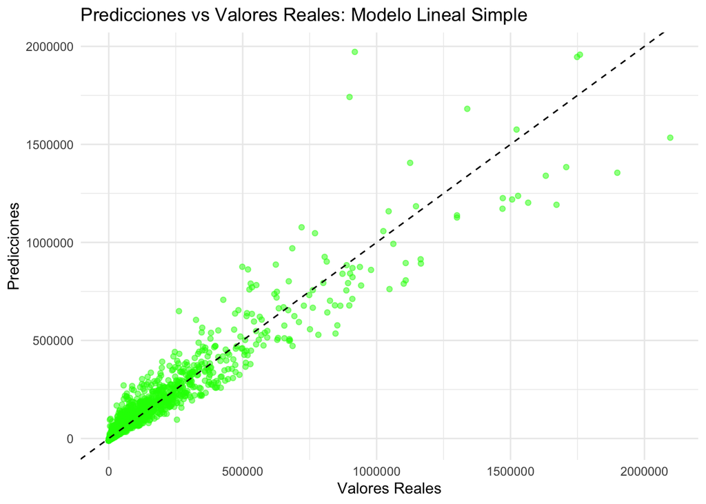

```r
# Graficar las predicciones vs los valores reales del modelo lineal simple
predicciones_lineal_df <- data.frame(
  Real = soja_prueba$produccion_tm,
  Prediccion_Lineal_Simple = predicciones_lineal_simple
)

ggplot(predicciones_lineal_df, aes(x = Real)) +
  geom_point(aes(y = Prediccion_Lineal_Simple), color = "green", alpha = 0.5) +
  geom_abline(slope = 1, intercept = 0, color = "black", linetype = "dashed") +
  theme_minimal() +
  labs(
    title = "Predicciones vs Valores Reales: Modelo Lineal Simple",
    x = "Valores Reales",
    y = "Predicciones"
  )
```

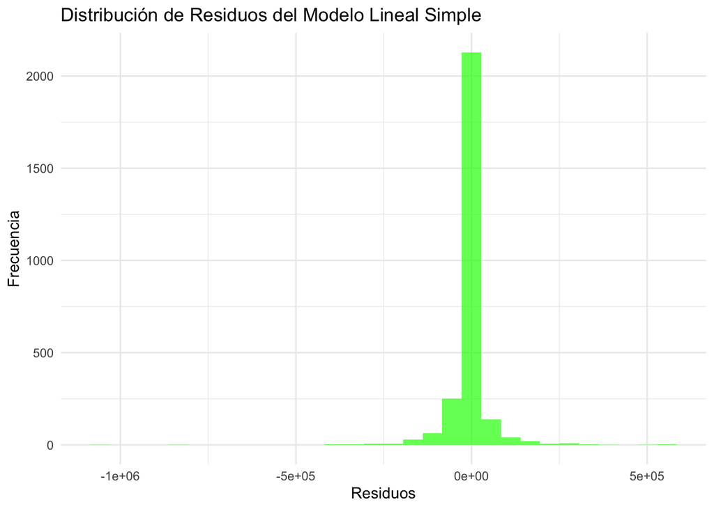

[output not shown]

```r
# Comparar los residuos del modelo lineal simple con los valores reales
residuos_lineal_simple_test <- soja_prueba$produccion_tm - predicciones_lineal_simple

# Crear un gráfico de los residuos
residuos_lineal_simple_df <- data.frame(
  Residuos = residuos_lineal_simple_test
)

ggplot(residuos_lineal_simple_df, aes(x = Residuos)) +
  geom_histogram(bins = 30, alpha = 0.7, fill = "green") +
  theme_minimal() +
  labs(title = "Distribución de Residuos del Modelo Lineal Simple",
       x = "Residuos", y = "Frecuencia")
```

La ecuación ajustada es:

$$\text{producción_tm} = -10220 + 3.021 \cdot
\text{superficie_cosechada_ha}$$

```
Coeficientes:
•   Intercepto: -10220, indica el valor esperado de la producción cuando la superficie cosechada es cero.
•   Pendiente: 3.021, muestra que por cada aumento de una hectárea cosechada, la producción aumenta en promedio 3.021 toneladas.
```

Estadísticas de Significancia: Ambos coeficientes son altamente significativos (p < 2e-16).

```
Ajuste del Modelo:
•   R^2: 0.9318, lo que indica que el modelo explica el 93.18% de la variabilidad en la producción.

Errores del Modelo:
•   Residual Standard Error: 54490, mide la dispersión de los residuos.
•   RMSE (Error Cuadrático Medio de Raíz): 58846.48, evalúa el error promedio del modelo en la misma escala que la variable dependiente.
•   MAE (Error Absoluto Medio): 26271.46, representa el error promedio absoluto.
•   MSE (Error Cuadrático Medio): 3462907826, muestra la magnitud del error promedio al cuadrado.
• R^2 del ajuste: 0.9083
```

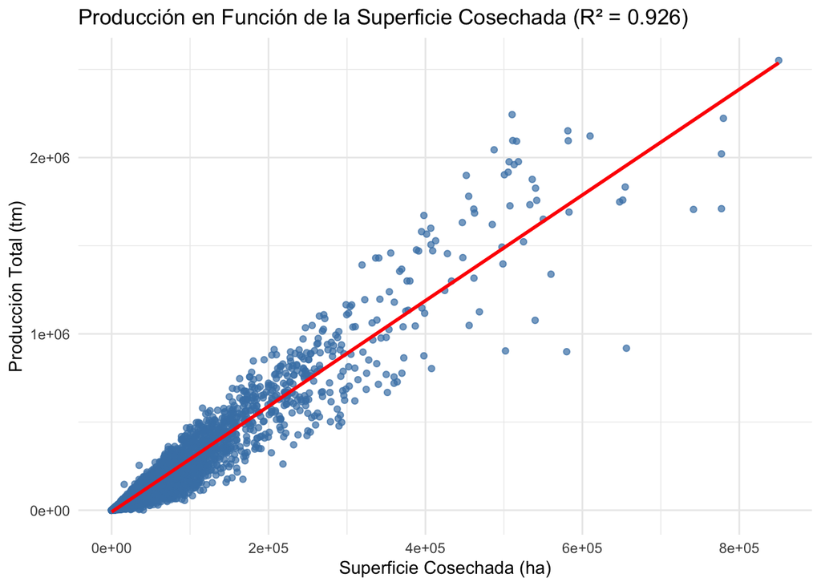

```r
library(broom)

# Ajustar el modelo lineal
modelo_lineal <- lm(produccion_tm ~ superficie_cosechada_ha, data = soja_data)

# Extraer el R²
r2 <- summary(modelo_lineal)$r.squared

# Crear el scatter plot con la regresión lineal y R²
ggplot(soja_data, aes(x = superficie_cosechada_ha, y = produccion_tm)) +
  geom_point(color = "steelblue", alpha = 0.7) +  # Puntos del scatter plot
  geom_smooth(method = "lm", se = TRUE, color = "red", fill = "lightgray") +  # Línea de regresión con intervalo de confianza
  theme_minimal() +
  labs(title = paste("Producción en Función de la Superficie Cosechada (R² = ", round(r2, 3), ")", sep = ""),
       x = "Superficie Cosechada (ha)",
       y = "Producción Total (tm)")
```

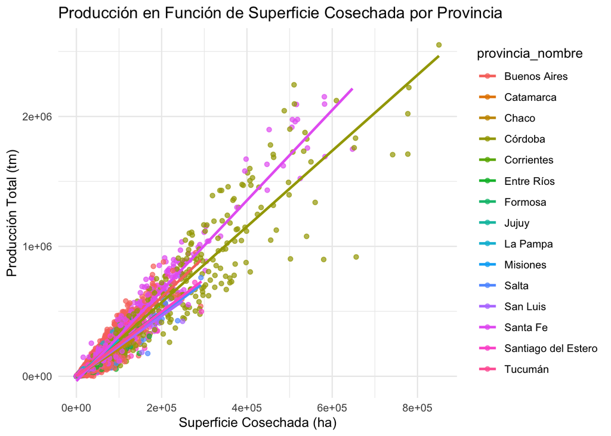

```r
# Ajustar un modelo lineal por provincia
modelos_por_provincia <- soja_data %>%
  group_by(provincia_nombre) %>%   # Agrupar por provincia
  do(modelo = lm(produccion_tm ~ superficie_cosechada_ha, data = .)) # Ajustar el modelo

# Ver el resumen de los modelos ajustados por provincia
resultados_modelos <- modelos_por_provincia %>%
  summarise(
    provincia = provincia_nombre,
    coef_intercepto = coef(modelo)[1],
    coef_superficie = coef(modelo)[2],
    r2 = summary(modelo)$r.squared
  )

# Visualización de las rectas de regresión para cada provincia con colores por provincia
ggplot(soja_data, aes(x = superficie_cosechada_ha, y = produccion_tm, color = provincia_nombre)) +
  geom_point(alpha = 0.7) +  # Puntos del scatter plot
  geom_smooth(method = "lm", se = FALSE, aes(group = provincia_nombre)) + # Línea de regresión por provincia
  theme_minimal() +
  labs(title = "Producción en Función de Superficie Cosechada por Provincia",
       x = "Superficie Cosechada (ha)",
       y = "Producción Total (tm)") +
  theme(legend.position = "right")  # Mostrar la leyenda de provincias
```

Esto nos da la pauta de que la superficie cosechada es un predictor importante de la producción de soja, pero también que hay diferencias significativas entre las provincias. Por lo tanto, es necesario ajustar un modelo lineal mixto para considerar estas diferencias y la estructura jerárquica de los datos.

```r
# Se procede con el modelo lineal mixto robusto

# Cargar la librería
library(robustlmm)

# Ajustar un modelo lineal mixto robusto con los datos de entrenamiento
modelo_robusto <- rlmer(produccion_tm ~ superficie_cosechada_ha + anio + cultivo_nombre +
                          (1 | provincia_nombre/departamento_nombre),
                        data = soja_entrenamiento)
# Resumen del modelo robusto
summary(modelo_robusto)
```

```
## Robust linear mixed model fit by DAStau
## Formula: produccion_tm ~ superficie_cosechada_ha + anio + cultivo_nombre +      (1 | provincia_nombre/departamento_nombre)
##    Data: soja_entrenamiento
##
## Scaled residuals:
##     Min      1Q  Median      3Q     Max
## -31.584  -0.436   0.059   0.431  41.744
##
## Random effects:
##  Groups                               Name        Variance  Std.Dev.
##  departamento_nombre:provincia_nombre (Intercept)  52087979  7217
##  provincia_nombre                     (Intercept)  13557889  3682
##  Residual                                         280270537 16741
## Number of obs: 6322, groups: departamento_nombre:provincia_nombre, 313; provincia_nombre, 15
##
## Fixed effects:
##                           Estimate Std. Error t value
## (Intercept)             -6.604e+05  7.982e+04    -8.3
## superficie_cosechada_ha  2.947e+00  5.111e-03   576.6
## anio                     3.264e+02  3.972e+01     8.2
## cultivo_nombresoja 2da  -4.175e+03  4.948e+02    -8.4
##
## Correlation of Fixed Effects:
##             (Intr) sprf__ anio
## sprfc_csch_  0.076
## anio        -1.000 -0.078
## cltv_nmbrs2  0.065  0.420 -0.068
##
## Robustness weights for the residuals:
##  4781 weights are ~= 1. The remaining 1541 ones are summarized as
##    Min. 1st Qu.  Median    Mean 3rd Qu.    Max.
##  0.0322  0.2660  0.4880  0.5130  0.7510  0.9990
##
## Robustness weights for the random effects:
##  273 weights are ~= 1. The remaining 55 ones are summarized as
##    Min. 1st Qu.  Median    Mean 3rd Qu.    Max.
##   0.205   0.356   0.542   0.581   0.806   0.988
##
## Rho functions used for fitting:
##   Residuals:
##     eff: smoothed Huber (k = 1.345, s = 10)
##     sig: smoothed Huber, Proposal 2 (k = 1.345, s = 10)
##   Random Effects, variance component 1 (departamento_nombre:provincia_nombre):
##     eff: smoothed Huber (k = 1.345, s = 10)
##     vcp: smoothed Huber, Proposal 2 (k = 1.345, s = 10)
##   Random Effects, variance component 2 (provincia_nombre):
##     eff: smoothed Huber (k = 1.345, s = 10)
##     vcp: smoothed Huber, Proposal 2 (k = 1.345, s = 10)
```

#Estructura del Modelo

Fórmula:
$$\text{producción_tm} = \beta_0
+ \beta_1 \cdot \text{superficie_cosechada_ha} + \beta_2 \cdot
\text{año} + \beta_3 \cdot \text{cultivo_nombre} + u_0 + v_0 +
\epsilon$$
• efecto aleatorio para cada provincia:
$$u_0 \sim N(0,
\sigma^2_{\text{provincia}})$$
• efecto aleatorio adicional para cada departamento:
$$v_0 \sim N(0,
\sigma^2_{\text{departamento dentro de provincia}})$$
• error residual robusto:
$$\epsilon \sim N(0,
\sigma^2_{\text{residual}})$$

```
Residuos Escalados
•   Mín. y Máx. Residuos Escalados:
•   Rango amplio (-31.584 a 41.744) indica algunos valores atípicos severos.
•   Mediana cercana a 0: Residuos están centrados, señal de un buen ajuste promedio.
```

#Componentes Aleatorios

Varianzas: • Residuales: 280,270,537 ( Desv. Est. = 16,741 ) • Efectos de Departamentos dentro de Provincias: 52,087,979 ( Desv. Est. = 7,217 ) • Efectos de Provincias: 13,557,889 ( Desv. Est. = 3,682 )

Interpretación: Los mayores efectos aleatorios provienen de los departamentos dentro de las provincias, pero los efectos residuales dominan la variabilidad.

#Efectos Fijos

Coeficientes Estimados: • (Intercepto): -660,400: Producción base ajustada. • superficie_cosechada_ha: 2.947: Cada hectárea adicional aumenta la producción en 2.947 toneladas (robusto y muy significativo). • año: 326.4: Incremento anual promedio en toneladas, probablemente debido a mejoras tecnológicas o climáticas. • cultivo_nombre soja 2da: -4,175: Producción promedio para “soja 2da” es menor en 4,175 toneladas respecto a la referencia.

Significación: • Todos los coeficientes son altamente significativos (t-values > 8).

```
Correlación entre Efectos Fijos
•   Alta correlación negativa entre el intercepto y el año (-1.00): el intercepto ajusta a los años más antiguos.
•   Correlación moderada (0.42) entre “soja 2da” y la superficie cosechada, indicando relación entre tipo de cultivo y área.

Robustez
•   Pesos de Residuos:
•   4781 residuos tienen pesos cercanos a 1, indicando un buen ajuste para la mayoría.
•   Los valores restantes tienen pesos menores, lo que sugiere un manejo robusto de valores atípicos.
•   Pesos de Efectos Aleatorios:
•   Departamentos/Provincias: Pesos más bajos para algunos grupos, sugiriendo estructuras heterogéneas.
```

Este modelo robusto lineal mixto captura adecuadamente las relaciones entre las variables explicativas y la producción. La inclusión de efectos aleatorios por provincias y departamentos mejora el ajuste al considerar las estructuras jerárquicas. La robustez garantiza que el modelo sea menos sensible a valores atípicos.

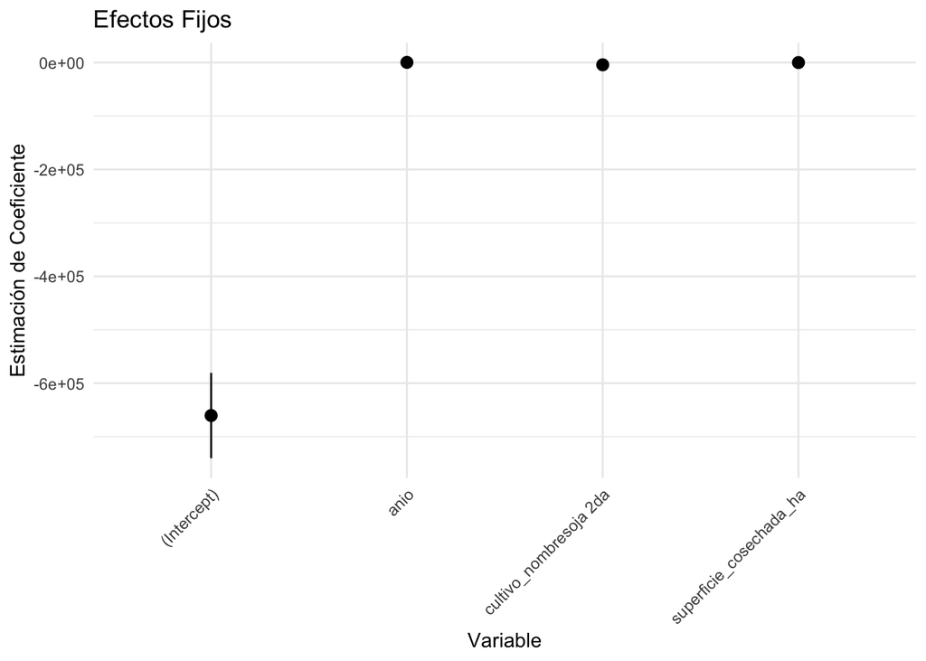

```r
# Gráfico de los efectos fijos

# Coeficientes de efectos fijos
coef_fijos <- summary(modelo_robusto)$coefficients

# Crear un gráfico de los efectos fijos
coef_fijos_df <- data.frame(
  Variable = rownames(coef_fijos),
  Estimate = coef_fijos[, "Estimate"],
  StdError = coef_fijos[, "Std. Error"]
)

ggplot(coef_fijos_df, aes(x = Variable, y = Estimate, ymin = Estimate - StdError, ymax = Estimate + StdError)) +
  geom_pointrange() +
  theme_minimal() +
  labs(title = "Efectos Fijos", y = "Estimación de Coeficiente", x = "Variable") +
  theme(axis.text.x = element_text(angle = 45, hjust = 1))
```

```r
# Efectos aleatorios
ranef(modelo_robusto)
```

```
## $`departamento_nombre:provincia_nombre`
##                                                   (Intercept)
## 12 de Octubre:Chaco                             -10446.757451
## 2 de Abril:Chaco                                 -5076.344353
## 25 de Mayo:Buenos Aires                           -301.988450
## 25 de Mayo:Chaco                                  7643.738757
## 25 de Mayo:Misiones                                648.031886
## 9 de Julio:Buenos Aires                           1862.361907
## 9 de Julio:Chaco                                 -6441.563254
## 9 de Julio:Santa Fe                             -20553.284560
## Adolfo Alsina:Buenos Aires                      -17896.637104
## Adolfo Gonzales Chaves:Buenos Aires             -32558.009976
## Aguirre:Santiago del Estero                       -630.433102
## Alberdi:Santiago del Estero                      -4679.156087
## Alberti:Buenos Aires                              3857.982270
## Almirante Brown:Chaco                            -6561.511310
## Anta:Salta                                      -27287.751319
## Arrecifes:Buenos Aires                           13994.906060
## Atreucó:La Pampa                                 -3999.137445
## Avellaneda:Santiago del Estero                    2005.118741
## Ayacucho:Buenos Aires                              168.785006
## Ayacucho:San Luis                                 5951.231045
## Azul:Buenos Aires                               -34927.299018
## Bahía Blanca:Buenos Aires                          409.754416
## Balcarce:Buenos Aires                           -18939.614027
## Banda:Santiago del Estero                         3900.158221
## Baradero:Buenos Aires                             4377.881458
## Belgrano:Santa Fe                                 8119.398489
## Belgrano:Santiago del Estero                    -13362.124224
## Bella Vista:Corrientes                            1254.578014
## Benito Juárez:Buenos Aires                      -27523.837356
## Bermejo:Chaco                                     6801.791787
## Bermejo:Formosa                                   2293.415692
## Berón de Astrada:Corrientes                        -65.242392
## Bolívar:Buenos Aires                             -3672.636761
## Bragado:Buenos Aires                              6831.820450
## Brandsen:Buenos Aires                              563.514455
## Burruyacú:Tucumán                                -8254.082960
## Cainguás:Misiones                                  726.208892
## Calamuchita:Córdoba                                512.073002
```

[output cut: 281 more lines]

```
## Córdoba              -3930.1704
## Corrientes            1675.4483
## Entre Ríos           -7864.0968
## Formosa                913.4667
## Jujuy                 2845.9603
## La Pampa               118.3826
## Misiones              2204.0846
## Salta                 -455.9741
## San Luis             -2710.2191
## Santa Fe              3540.3780
## Santiago del Estero  -1304.5799
## Tucumán               1060.0248
##
## attr(,"class")
## [1] "ranef.rlmerMod"
```

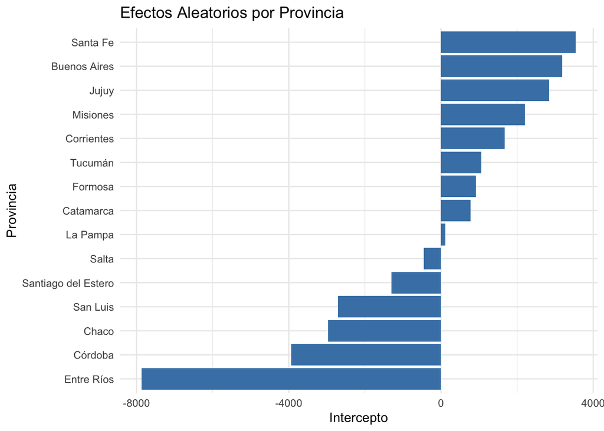

```r
# Extraer los efectos aleatorios por provincia para visualizar
efectos_provincia <- ranef(modelo_robusto)$provincia_nombre
efectos_provincia_df <- data.frame(
  provincia = rownames(efectos_provincia),
  intercepto = efectos_provincia[, "(Intercept)"]
)

# Ordenar las provincias por el valor del intercepto
efectos_provincia_df <- efectos_provincia_df[order(efectos_provincia_df$intercepto), ]

# Crear el gráfico
ggplot(efectos_provincia_df, aes(x = reorder(provincia, intercepto), y = intercepto)) +
  geom_bar(stat = "identity", fill = "steelblue") +
  coord_flip() +  # Para que las provincias aparezcan en el eje y
  labs(
    title = "Efectos Aleatorios por Provincia",
    x = "Provincia",
    y = "Intercepto"
  ) +
  theme_minimal()
```

Queda un poco fuera de escala el gráfico, con las variables normalizadas se vería mejor, aunque se pierde un poco de interpretación y no mejoran significativamente los resultados.

```r
# Comparo con el modelo no robusto

# Cargar la librería lme4
library(lme4)

# Ajustar el modelo lineal mixto estándar con los datos de entrenamiento
modelo_estandar <- lmer(produccion_tm ~ superficie_cosechada_ha + anio + cultivo_nombre +
                          (1 | provincia_nombre/departamento_nombre),
                        data = soja_entrenamiento)
# Resumen del modelo estándar
summary(modelo_estandar)
```

```
## Linear mixed model fit by REML ['lmerMod']
## Formula: produccion_tm ~ superficie_cosechada_ha + anio + cultivo_nombre +
##     (1 | provincia_nombre/departamento_nombre)
##    Data: soja_entrenamiento
##
## REML criterion at convergence: 154752.9
##
## Scaled residuals:
##      Min       1Q   Median       3Q      Max
## -10.0559  -0.1562   0.0479   0.2287  12.0404
##
## Random effects:
##  Groups                               Name        Variance  Std.Dev.
##  departamento_nombre:provincia_nombre (Intercept) 5.187e+08 22775
##  provincia_nombre                     (Intercept) 4.597e+07  6780
##  Residual                                         2.324e+09 48203
## Number of obs: 6322, groups:
## departamento_nombre:provincia_nombre, 313; provincia_nombre, 15
##
## Fixed effects:
##                           Estimate Std. Error t value
## (Intercept)             -1.694e+06  2.242e+05  -7.553
## superficie_cosechada_ha  3.027e+00  1.441e-02 210.017
## anio                     8.386e+02  1.116e+02   7.516
## cultivo_nombresoja 2da  -6.734e+03  1.389e+03  -4.847
##
## Correlation of Fixed Effects:
##             (Intr) sprf__ anio
## sprfc_csch_  0.076
## anio        -1.000 -0.079
## cltv_nmbrs2  0.065  0.421 -0.068
## fit warnings:
## Some predictor variables are on very different scales: consider rescaling
```

Componentes Aleatorios

Varianzas:

```
•   Departamentos dentro de Provincias:  518,700,000  ( Desv. Est. = 22,775 )

•   Provincias:  45,970,000  ( Desv. Est. = 6,780 )

•   Residuales:  2,324,000,000  ( Desv. Est. = 48,203 )
```

Interpretación:

```
•   La mayor parte de la variabilidad sigue siendo explicada por los residuos, pero los efectos aleatorios jerárquicos son significativos, especialmente a nivel de departamentos dentro de provincias.
```

Efectos Fijos

Coeficientes Estimados:

```
•   (Intercepto): -1,694,000: Producción base ajustada.

•   superficie_cosechada_ha: 3.027: Cada hectárea adicional aumenta la producción en 3.027 toneladas (significativo).

•   año: 838.6: Incremento promedio anual en producción, posiblemente debido a factores externos como tecnología o clima.

•   cultivo_nombresoja 2da: -6,734: Producción promedio de “soja 2da” es menor en 6,734 toneladas respecto a la referencia.
```

Significación:

```
•   Todos los coeficientes son estadísticamente significativos (t > 4.8).
```

```r
#   Aspecto             Modelo REML             Modelo Robusto
# Varianza Residual 2.324e+09 (48,203)      2.802e+08 (16,741)
# Random Effects (Deptos)   518.7e+06 (22,775)  52.1e+06 (7,217)
# Fixed Effect (superficie) 3.027               2.947
# Fixed Effect (cultivo)    -6,734              -4,175

# Crear un data frame con los aspectos y resultados
aspectos <- data.frame(
  Aspecto = c("Varianza Residual", "Random Effects (Deptos)", "Fixed Effect (superficie)", "Fixed Effect (cultivo)"),
  `Modelo REML` = c("2.324e+09", "518.7e+06", "3.027", "-6,734"),
  `Modelo Robusto` = c("2.802e+08", "52.1e+06", "2.947", "-4,175")
)

# Mostrar la tabla formateada
print(aspectos)
```

```
##                     Aspecto Modelo.REML Modelo.Robusto
## 1         Varianza Residual   2.324e+09      2.802e+08
## 2   Random Effects (Deptos)   518.7e+06       52.1e+06
## 3 Fixed Effect (superficie)       3.027          2.947
## 4    Fixed Effect (cultivo)      -6,734         -4,175
```

[output not shown]

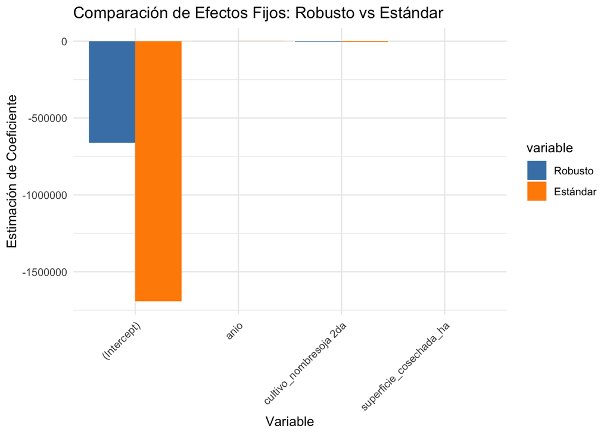

```r
# Extraer coeficientes de efectos fijos del modelo estándar
coef_estandar <- summary(modelo_estandar)$coefficients

# Unir los coeficientes de ambos modelos en un dataframe
comparacion_coef <- data.frame(
  Variable = rownames(coef_fijos),
  Estimacion_Robusta = coef_fijos[, "Estimate"],
  Estimacion_Estandar = coef_estandar[, "Estimate"]
)

# Visualizar la comparación
library(reshape2)
comparacion_long <- melt(comparacion_coef, id.vars = "Variable")

ggplot(comparacion_long, aes(x = Variable, y = value, fill = variable)) +
  geom_bar(stat = "identity", position = "dodge") +
  theme_minimal() +
  labs(title = "Comparación de Efectos Fijos: Robusto vs Estándar",
       y = "Estimación de Coeficiente", x = "Variable") +
  theme(axis.text.x = element_text(angle = 45, hjust = 1)) +
  scale_fill_manual(values = c("steelblue", "darkorange"), labels = c("Robusto", "Estándar"))
```

[figure not shown]

```r
# Efectos aleatorios del modelo estándar
efectos_provincia_estandar <- ranef(modelo_estandar)$provincia_nombre
efectos_comparacion <- data.frame(
  provincia = rownames(efectos_provincia),
  Intercepto_Robusto = efectos_provincia[, "(Intercept)"],
  Intercepto_Estandar = efectos_provincia_estandar[, "(Intercept)"]
)

# Visualizar la comparación con un gráfico
efectos_comparacion %>%
  pivot_longer(cols = c(Intercepto_Robusto, Intercepto_Estandar), names_to = "Modelo", values_to = "Valor") %>%
  ggplot(aes(x = reorder(provincia, Valor), y = Valor, fill = Modelo)) +
  geom_bar(stat = "identity", position = "dodge") +
  coord_flip() +
  labs(
    title = "Comparación de Efectos Aleatorios: Robusto vs Estándar",
    x = "Provincia", y = "Intercepto"
  ) +
  theme_minimal() +
  scale_fill_manual(values = c("steelblue", "darkorange"), labels = c("Robusto", "Estándar"))
```

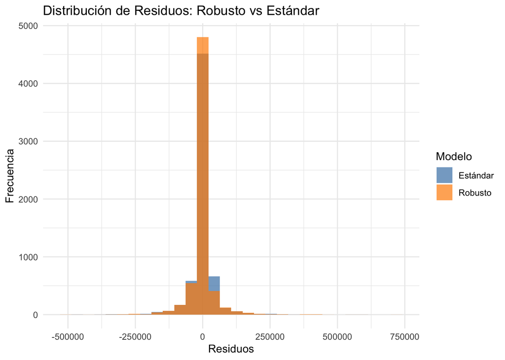

```r
# Residuos de ambos modelos
residuos_robusto <- residuals(modelo_robusto)
residuos_estandar <- residuals(modelo_estandar)

# Visualización de los residuos
residuos_df <- data.frame(
  Residuos = c(residuos_robusto, residuos_estandar),
  Modelo = rep(c("Robusto", "Estándar"), each = length(residuos_robusto))
)

ggplot(residuos_df, aes(x = Residuos, fill = Modelo)) +
  geom_histogram(bins = 30, alpha = 0.7, position = "identity") +
  theme_minimal() +
  labs(title = "Distribución de Residuos: Robusto vs Estándar", x = "Residuos", y = "Frecuencia") +
  scale_fill_manual(values = c("steelblue",  "darkorange"))
```

Conclusión

El modelo ajustado por REML confirma relaciones clave entre las variables y la producción, con buena significación en los efectos fijos y jerarquías bien modeladas en los efectos aleatorios. Sin embargo, el modelo robusto parece manejar mejor los valores atípicos, resultando en una varianza residual menor y un ajuste más robusto.

```r
# Predicción y evaluación del modelo en los datos de prueba

# Realizar predicciones con el modelo robusto en el conjunto de prueba
predicciones_robusto <- predict(modelo_robusto, newdata = soja_prueba)

# Realizar predicciones con el modelo estándar en el conjunto de prueba
predicciones_estandar <- predict(modelo_estandar, newdata = soja_prueba)

# Calcular el error cuadrático medio (RMSE) para ambos modelos
rmse_robusto <- sqrt(mean((soja_prueba$produccion_tm - predicciones_robusto)^2))
rmse_estandar <- sqrt(mean((soja_prueba$produccion_tm - predicciones_estandar)^2))

# Calcular el MAE (Mean Absolute Error)
mae_robusto <- mean(abs(soja_prueba$produccion_tm - predicciones_robusto))
mae_estandar <- mean(abs(soja_prueba$produccion_tm - predicciones_estandar))

# Calcular el MSE (Mean Squared Error)
mse_robusto <- mean((soja_prueba$produccion_tm - predicciones_robusto)^2)
mse_estandar <- mean((soja_prueba$produccion_tm - predicciones_estandar)^2)

# Calcular el R² (Coeficiente de determinación)
r2_robusto <- 1 - sum((soja_prueba$produccion_tm - predicciones_robusto)^2) / sum((soja_prueba$produccion_tm - mean(soja_prueba$produccion_tm))^2)
r2_estandar <- 1 - sum((soja_prueba$produccion_tm - predicciones_estandar)^2) / sum((soja_prueba$produccion_tm - mean(soja_prueba$produccion_tm))^2)


# Mostrar los resultados
cat("RMSE del modelo robusto:", rmse_robusto, "\n")
```

```
## RMSE del modelo robusto: 55017.28
```

```r
cat("RMSE del modelo estándar:", rmse_estandar, "\n")
```

```
## RMSE del modelo estándar: 53063.35
```

```r
cat("MAE del modelo robusto:", mae_robusto, "\n")
```

```
## MAE del modelo robusto: 23119.63
```

```r
cat("MAE del modelo estándar:", mae_estandar, "\n")
```

```
## MAE del modelo estándar: 25289.67
```

```r
cat("MSE del modelo robusto:", mse_robusto, "\n")
```

```
## MSE del modelo robusto: 3026901318
```

```r
cat("MSE del modelo estándar:", mse_estandar, "\n")
```

```
## MSE del modelo estándar: 2815719533
```

```r
cat("R² del modelo robusto:", r2_robusto, "\n")
```

```
## R² del modelo robusto: 0.9198814
```

```r
cat("R² del modelo estándar:", r2_estandar, "\n")
```

```
## R² del modelo estándar: 0.9254712
```

```r
# <!-- Métrica  Modelo Robusto  Modelo Estándar   Modelo lineal simple -->
# <!-- RMSE     55,017.28           53,063.35           58846.48  -->
# <!-- MAE  23,119.63           25,289.67           26271.46  -->
# <!-- MSE  3,026,901,318       2,815,719,533       3,462,907,826  -->
# <!-- R^2      0.9199            0.9255              0.9083408  -->

# Crear un data frame con las métricas
metricas <- data.frame(
  Métrica = c("RMSE", "MAE", "MSE", "R²"),
  `Modelo Robusto` = c(55017.28, 23119.63, 3026901318, 0.9199),
  `Modelo Estándar` = c(53063.35, 25289.67, 2815719533, 0.9255),
  `Modelo Lineal Simple` = c(58846.48, 26271.46, 3462907826, 0.9083)
)

# Mostrar la tabla formateada
print(metricas)
```

```
##   Métrica Modelo.Robusto Modelo.Estándar Modelo.Lineal.Simple
## 1    RMSE   5.501728e+04    5.306335e+04         5.884648e+04
## 2     MAE   2.311963e+04    2.528967e+04         2.627146e+04
## 3     MSE   3.026901e+09    2.815720e+09         3.462908e+09
## 4      R²   9.199000e-01    9.255000e-01         9.083000e-01
```

```
1.  Modelo estándar:
•   Presenta el mejor desempeño global en términos de  RMSE ,  MSE  y  R^2 .
•   Explica un 92.55% de la variabilidad en los datos, lo que es superior a los otros modelos.

2.  Modelo robusto:
•   Aunque no tiene los mejores  RMSE  o  MSE , el MAE más bajo sugiere que tiene errores promedio más pequeños y estables.
•   Es más resistente a la influencia de valores atípicos, lo que lo hace más confiable en presencia de ruido o datos extremos.

3.  Modelo lineal simple:
•   Es el más débil en todas las métricas.
•    RMSE  y  MSE  son significativamente más altos debido a la falta de términos de ajuste adicionales (efectos aleatorios y covariables importantes como el año y el tipo de cultivo).
```

Conclusión: El modelo estándar tiene un ajuste más preciso según el RMSE y el R^2 , pero el modelo robusto es más confiable en escenarios donde los datos presentan valores atípicos significativos.

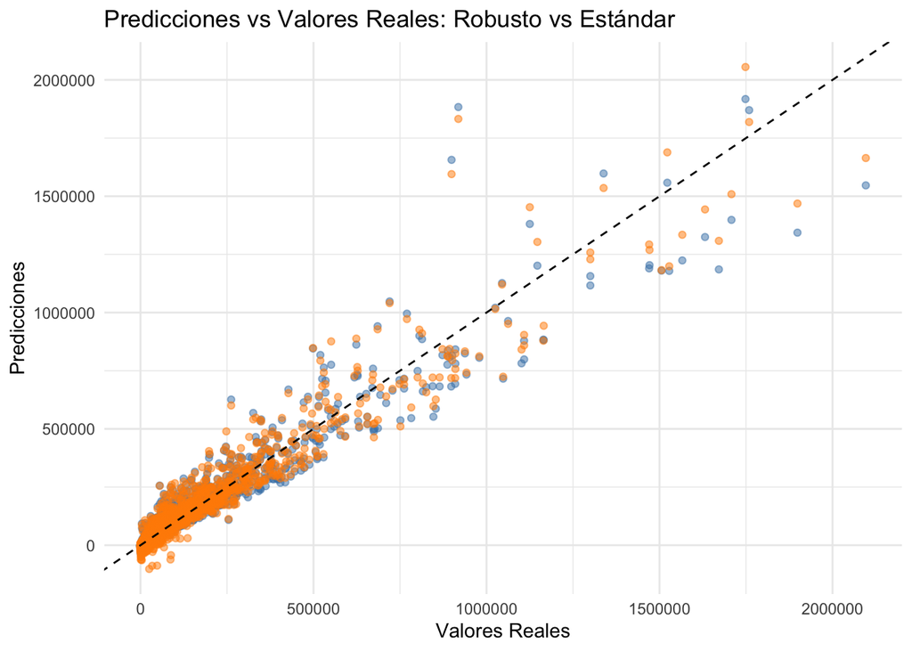

```r
# Graficar las predicciones vs los valores reales
predicciones_df <- data.frame(
  Real = soja_prueba$produccion_tm,
  Prediccion_Robusta = predicciones_robusto,
  Prediccion_Estandar = predicciones_estandar
)

ggplot(predicciones_df, aes(x = Real)) +
  geom_point(aes(y = Prediccion_Robusta), color = "steelblue", alpha = 0.5) +
  geom_point(aes(y = Prediccion_Estandar), color = "darkorange", alpha = 0.5) +
  geom_abline(slope = 1, intercept = 0, color = "black", linetype = "dashed") +
  theme_minimal() +
  labs(
    title = "Predicciones vs Valores Reales: Robusto vs Estándar",
    x = "Valores Reales",
    y = "Predicciones"
  )
```

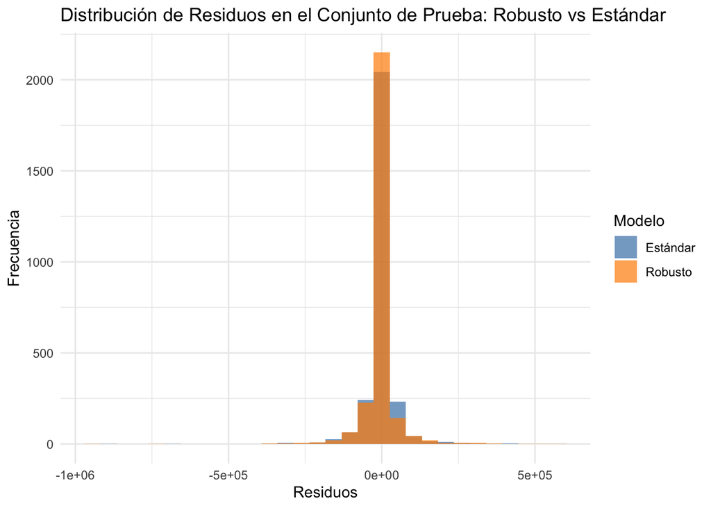

```r
# Comparar los residuos de las predicciones con los valores reales
residuos_robusto_test <- soja_prueba$produccion_tm - predicciones_robusto
residuos_estandar_test <- soja_prueba$produccion_tm - predicciones_estandar

# Crear un gráfico de los residuos
residuos_test_df <- data.frame(
  Residuos = c(residuos_robusto_test, residuos_estandar_test),
  Modelo = rep(c("Robusto", "Estándar"), each = length(residuos_robusto_test))
)

ggplot(residuos_test_df, aes(x = Residuos, fill = Modelo)) +
  geom_histogram(bins = 30, alpha = 0.7, position = "identity") +
  theme_minimal() +
  labs(title = "Distribución de Residuos en el Conjunto de Prueba: Robusto vs Estándar",
       x = "Residuos", y = "Frecuencia") +
  scale_fill_manual(values = c("steelblue", "darkorange"))
```